# Lecture 16 - Data Wrangling

2022-11-16

## Packages for this lecture

```r
library(tidyverse)
library(nycflights13)
library(babynames)
```

## Data Wrangling

- Often you have many tables of data and need to combine them to answer a question
- Multiple tables of data are called *relational data* because we are interested in the relations rather than the individual data sets

## `nycflights13` Data

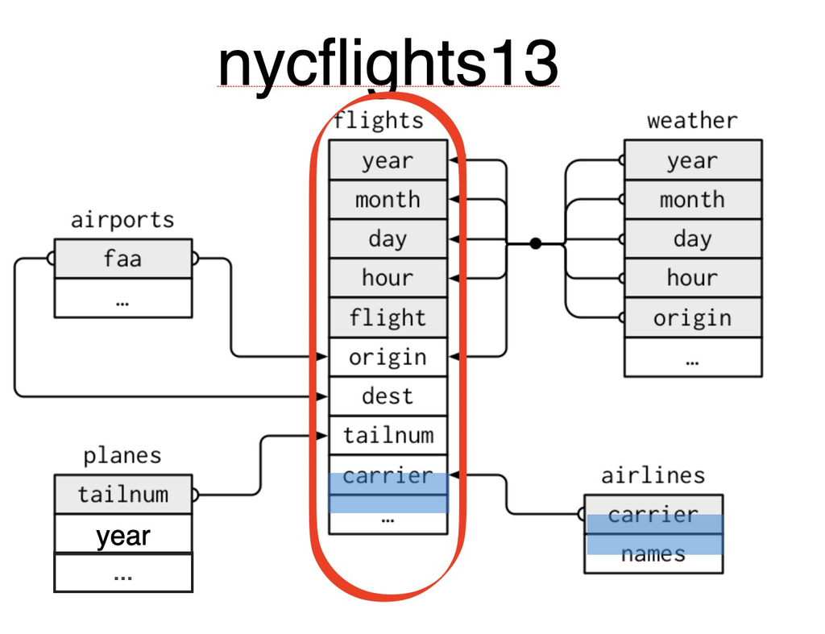

## Relational data

Need verbs that work with pairs of tables. There are 3 families of verbs:

- **Mutating joins** - add new variables to one data frame from matching observations in another
- **Filtering joins** - filter observations from one data frame based on whether or not they match an observation in the other table
- **Set operations** - treat observations as if they were set elements

## Toy example

```r
band <- tribble(
   ~name,   ~band,
  "Mick", "Stones",
  "John", "Beetles",
  "Paul", "Beetles"
)

instrument <- tribble(
  ~name, ~plays,
  "John", "guitar",
  "Paul", "bass",
  "Keith", "guitar"
)
```

## Toy example

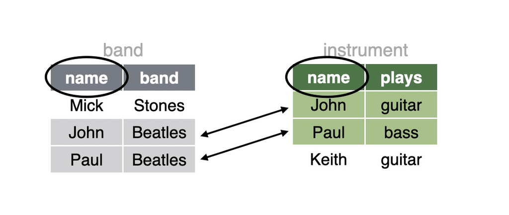

## Join

```r
left_join(band,instrument, by ="name")
```

```
## # A tibble: 3 × 3
##   name  band    plays
##   <chr> <chr>   <chr>
## 1 Mick  Stones  <NA>
## 2 John  Beetles guitar
## 3 Paul  Beetles bass
```

```r
right_join(band,instrument, by ="name")
```

```
## # A tibble: 3 × 3
##   name  band    plays
##   <chr> <chr>   <chr>
## 1 John  Beetles guitar
## 2 Paul  Beetles bass
## 3 Keith <NA>    guitar
```

```r
inner_join(band,instrument, by ="name")
```

```
## # A tibble: 2 × 3
##   name  band    plays
##   <chr> <chr>   <chr>
## 1 John  Beetles guitar
## 2 Paul  Beetles bass
```

```r
full_join(band,instrument, by ="name")
```

```
## # A tibble: 4 × 3
##   name  band    plays
##   <chr> <chr>   <chr>
## 1 Mick  Stones  <NA>
## 2 John  Beetles guitar
## 3 Paul  Beetles bass
## 4 Keith <NA>    guitar
```

## Your turn

Which airlines had the largest arrival delays (on average)?

## Different variable names¶

```r
band <- tribble(
   ~name,   ~band,
  "Mick", "Stones",
  "John", "Beetles",
  "Paul", "Beetles"
)

instrument2 <- tribble(
  ~artist, ~plays,
  "John", "guitar",
  "Paul", "bass",
  "Keith", "guitar"
)
```

```r
left_join(band,instrument2, by = c("name" = "artist" ))
```

```
## # A tibble: 3 × 3
##   name  band    plays
##   <chr> <chr>   <chr>
## 1 Mick  Stones  <NA>
## 2 John  Beetles guitar
## 3 Paul  Beetles bass
```

## Your turn

We can investigate the relationship between distance and the delay. Join flights and airports by dest and faa. Then for each name, compute the distance from NYC and the average arr_delay. (use first() to get the first value of distance.) Order by average delay, worst to best.

## Filtering joins

```r
semi_join(band,instrument, by ="name")
```

```
## # A tibble: 2 × 2
##   name  band
##   <chr> <chr>
## 1 John  Beetles
## 2 Paul  Beetles
```

```r
anti_join(band,instrument, by ="name")
```

```
## # A tibble: 1 × 2
##   name  band
##   <chr> <chr>
## 1 Mick  Stones
```

## Your turn

How many airports can you fly to direct from New York? Notice that the column to filter on is named faa in the airports dataset and dest in the flights dataset.)

## Review of joins

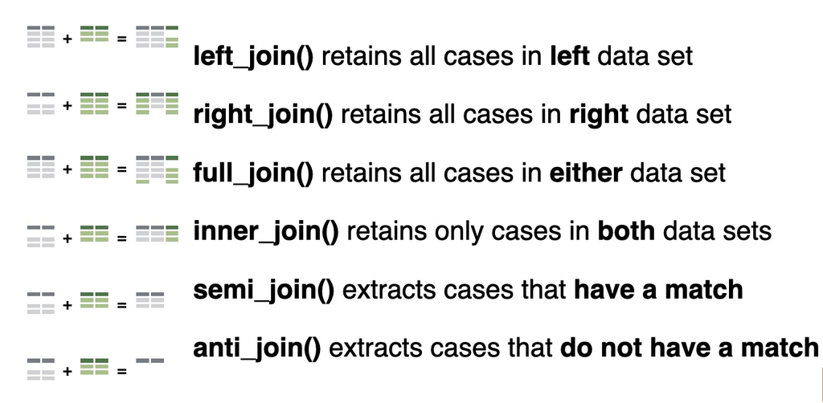

## Tidy data

```
## # A tibble: 6 × 4
##   country      year  cases population
##   <chr>       <int>  <int>      <int>
## 1 Afghanistan  1999    745   19987071
## 2 Afghanistan  2000   2666   20595360
## 3 Brazil       1999  37737  172006362
## 4 Brazil       2000  80488  174504898
## 5 China        1999 212258 1272915272
## 6 China        2000 213766 1280428583
```

```
## # A tibble: 12 × 4
##    country      year type            count
##    <chr>       <int> <chr>           <int>
##  1 Afghanistan  1999 cases             745
##  2 Afghanistan  1999 population   19987071
##  3 Afghanistan  2000 cases            2666
##  4 Afghanistan  2000 population   20595360
##  5 Brazil       1999 cases           37737
##  6 Brazil       1999 population  172006362
##  7 Brazil       2000 cases           80488
##  8 Brazil       2000 population  174504898
##  9 China        1999 cases          212258
## 10 China        1999 population 1272915272
## 11 China        2000 cases          213766
## 12 China        2000 population 1280428583
```

```
## # A tibble: 6 × 3
##   country      year rate
## * <chr>       <int> <chr>
## 1 Afghanistan  1999 745/19987071
## 2 Afghanistan  2000 2666/20595360
## 3 Brazil       1999 37737/172006362
## 4 Brazil       2000 80488/174504898
## 5 China        1999 212258/1272915272
## 6 China        2000 213766/1280428583
```

```
## # A tibble: 3 × 3
##   country     `1999` `2000`
## * <chr>        <int>  <int>
## 1 Afghanistan    745   2666
## 2 Brazil       37737  80488
## 3 China       212258 213766
```

```
## # A tibble: 3 × 3
##   country         `1999`     `2000`
## * <chr>            <int>      <int>
## 1 Afghanistan   19987071   20595360
## 2 Brazil       172006362  174504898
## 3 China       1272915272 1280428583
```

```
## # A tibble: 6 × 4
##   country     century year  rate
## * <chr>       <chr>   <chr> <chr>
## 1 Afghanistan 19      99    745/19987071
## 2 Afghanistan 20      00    2666/20595360
## 3 Brazil      19      99    37737/172006362
## 4 Brazil      20      00    80488/174504898
## 5 China       19      99    212258/1272915272
## 6 China       20      00    213766/1280428583
```

## `pivot_longer()`

```r
cases <- tribble(
  ~country, ~"2011", ~"2012",~"2013",
  "FR",  7000, 6900, 7000,
  "DE",  5800, 6000, 6200,
  "US", 15000,14000,13000
)
```

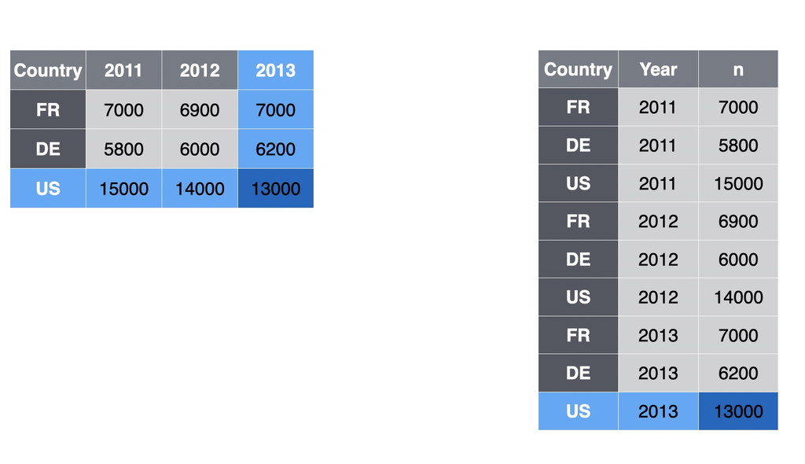

```r
cases
```

```
## # A tibble: 3 × 4
##   country `2011` `2012` `2013`
##   <chr>    <dbl>  <dbl>  <dbl>
## 1 FR        7000   6900   7000
## 2 DE        5800   6000   6200
## 3 US       15000  14000  13000
```

```r
cases %>% pivot_longer(2:4, names_to = "year", values_to = "n")
```

```
## # A tibble: 9 × 3
##   country year      n
##   <chr>   <chr> <dbl>
## 1 FR      2011   7000
## 2 FR      2012   6900
## 3 FR      2013   7000
## 4 DE      2011   5800
## 5 DE      2012   6000
## 6 DE      2013   6200
## 7 US      2011  15000
## 8 US      2012  14000
## 9 US      2013  13000
```

We can use a similar syntax for selecting the columns

```r
cases
```

```
## # A tibble: 3 × 4
##   country `2011` `2012` `2013`
##   <chr>    <dbl>  <dbl>  <dbl>
## 1 FR        7000   6900   7000
## 2 DE        5800   6000   6200
## 3 US       15000  14000  13000
```

```r
cases %>% pivot_longer(c("2011","2012","2013"),
                       names_to = "year", values_to  = "n" )
cases %>% pivot_longer( -1, names_to  = "year", values_to = "n")
cases %>% pivot_longer( -country, names_to = "year", values_to = "n")
cases %>% pivot_longer(starts_with("2"), names_to = "year",
                       values_to = "n")
```

## Your turn

Use `pivot_longer()` to reorganize table4a into three columns: `country`, `year`, and `cases`.

## `pivot_wider()`

```r
pollution <- tribble(
  ~city,   ~size, ~amount,
  "New York", "large",     23,
  "New York", "small",     14,
  "London", "large",       22,
  "London", "small",       16,
  "Beijing", "large",      121,
  "Beijing", "small",      56
)
```

## `pivot_wider()`

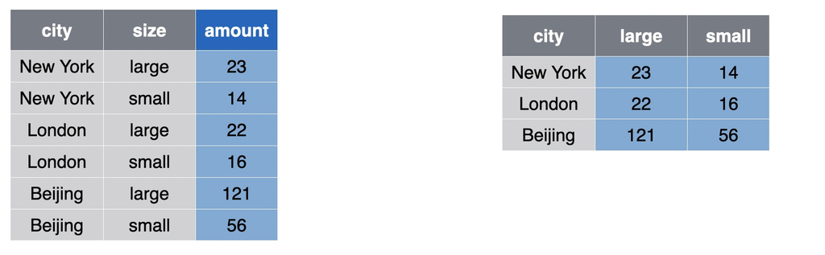

```r
pollution %>% pivot_wider(names_from = size, values_from = amount)
```

```
## # A tibble: 3 × 3
##   city     large small
##   <chr>    <dbl> <dbl>
## 1 New York    23    14
## 2 London      22    16
## 3 Beijing    121    56
```

## Your turn

Use `pivot_wider()` to reorganize table2 into four columns: `country`, `year`, `cases`, and `population`.

## `who` data

The data contain tuberculosis (TB) cases broken down by year, country, age, gender, and diagnosis method from the 2014 World Health Organization Global Tuberculosis Report

```
-   `country`, `iso2`, `iso3` - country identifiers
-   `year` - year
-   other columns names - encode type of TB case, sex, and age
```

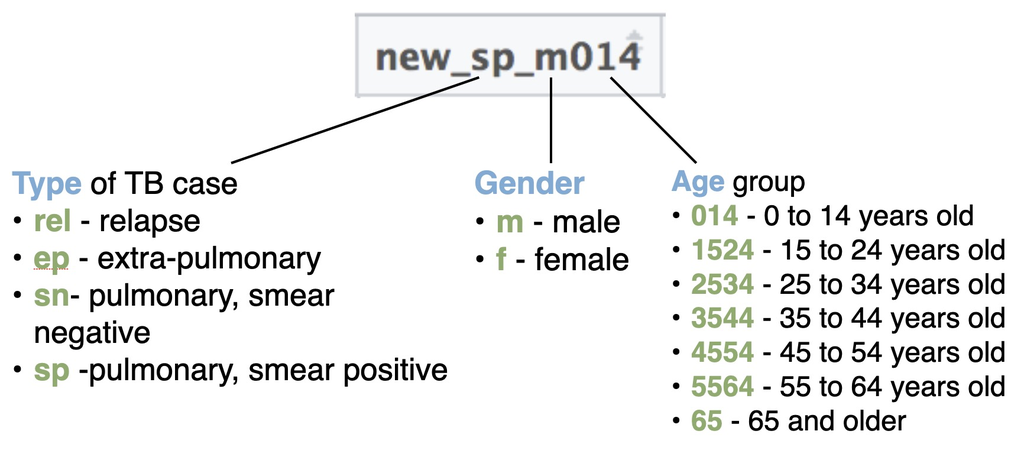

## Your turn

```r
names(who) <- str_replace(names(who), "newrel", "new_rel")
```

- Confirm that iso2 and iso3 were redundant with country (Hint: if iso2 and iso3 are redundant with country, then, within each country, there should only be one distinct combination of iso2 and iso3 values.)
- Pivot the 5th through 60th columns of who into a pair of key:value columns named codes and n. Then select just the country, year, codes and n variables.

## `separate()`

```r
who %>% pivot_longer(5:60, names_to = "codes", values_to = "n" ) %>%
  select(-iso2,-iso3) %>%
  separate(codes,into = c("new", "type", "sexage"), sep = "_")
```

```
## # A tibble: 405,440 × 6
##    country      year new   type  sexage     n
##    <chr>       <int> <chr> <chr> <chr>  <int>
##  1 Afghanistan  1980 new   sp    m014      NA
##  2 Afghanistan  1980 new   sp    m1524     NA
##  3 Afghanistan  1980 new   sp    m2534     NA
##  4 Afghanistan  1980 new   sp    m3544     NA
##  5 Afghanistan  1980 new   sp    m4554     NA
##  6 Afghanistan  1980 new   sp    m5564     NA
##  7 Afghanistan  1980 new   sp    m65       NA
##  8 Afghanistan  1980 new   sp    f014      NA
##  9 Afghanistan  1980 new   sp    f1524     NA
## 10 Afghanistan  1980 new   sp    f2534     NA
## # … with 405,430 more rows
```

## Your turn

- Separate the sexage column into sex and age columns.
- Calculate rate (in numeric) in table3

## `unite()`

Unites columns into single column by combining cells.

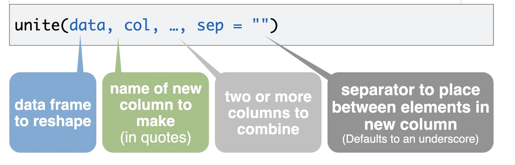

## unite()

```r
who %>%
  pivot_longer(5:60, names_to = "codes", values_to = "n" ) %>%
  select(-iso2, -iso3) %>%
  separate(codes, c("new", "type", "sexage"), sep = "_") %>%
  select(-new) %>%
  separate(sexage, into = c("sex", "age"), sep = 1,convert=TRUE) %>%
  unite("sexage2", sex, age, sep = "-")
```

```
## # A tibble: 405,440 × 5
##    country      year type  sexage2     n
##    <chr>       <int> <chr> <chr>   <int>
##  1 Afghanistan  1980 sp    m-14       NA
##  2 Afghanistan  1980 sp    m-1524     NA
##  3 Afghanistan  1980 sp    m-2534     NA
##  4 Afghanistan  1980 sp    m-3544     NA
##  5 Afghanistan  1980 sp    m-4554     NA
##  6 Afghanistan  1980 sp    m-5564     NA
##  7 Afghanistan  1980 sp    m-65       NA
##  8 Afghanistan  1980 sp    f-14       NA
##  9 Afghanistan  1980 sp    f-1524     NA
## 10 Afghanistan  1980 sp    f-2534     NA
## # … with 405,430 more rows
```

## Reshaping

Can we calculate the yearly percent of boys (or girls), i.e., male/(male+female)*100?

```r
babynames %>%
  group_by(year, sex) %>%
  summarize(n = sum(n))
```

```
## # A tibble: 276 × 3
## # Groups:   year [138]
##     year sex        n
##    <dbl> <chr>  <int>
##  1  1880 F      90993
##  2  1880 M     110491
##  3  1881 F      91953
##  4  1881 M     100743
##  5  1882 F     107847
##  6  1882 M     113686
##  7  1883 F     112319
##  8  1883 M     104627
##  9  1884 F     129020
## 10  1884 M     114442
## # … with 266 more rows
```

## Your turn

```r
babynames %>%
  group_by(year, sex) %>%
  summarize(n = sum(n))
```

Extend this code to reshape the data. Calculate the percent of male and female children by year. Then plot the percent over time.